# Exploratory Data Analysis of SAFI Survey Data

Short Analytical Report

2026-01-20

## 1. Data description

This report provides a short exploratory data analysis (EDA) of the **SAFI survey dataset**.

**Unit of observation:** each row represents one household.

**Variables:** columns contain household characteristics, location identifiers, food consumption indicators, agricultural information, and related survey attributes.

**Goal of EDA:** quickly check the structure of the data, basic numeric distributions, missingness, and a few simple relationships using `dplyr` for selection/filtering and `ggplot2` for plots.

## 2. Data loading

```r
library(dplyr)
library(ggplot2)
library(readr)
```

```r
# If SAFI_clean.csv is in the same folder as this .Rmd
safi <- read_csv("data/SAFI_clean.csv")
```

```r
# Data structure: column names, types, and example values
# This helps confirm that the dataset is loaded correctly.
glimpse(safi)
```

```
## Rows: 131
## Columns: 14
## $ key_ID               <dbl> 1, 2, 3, 4, 5, 6, 7, 8, 9, 10, 11, 12, 13, 14, 15…
## $ village              <chr> "God", "God", "God", "God", "God", "God", "God", …
## $ interview_date       <dttm> 2016-11-17, 2016-11-17, 2016-11-17, 2016-11-17, …
## $ no_membrs            <dbl> 3, 7, 10, 7, 7, 3, 6, 12, 8, 12, 6, 7, 6, 10, 5, …
## $ years_liv            <dbl> 4, 9, 15, 6, 40, 3, 38, 70, 6, 23, 20, 20, 8, 20,…
## $ respondent_wall_type <chr> "muddaub", "muddaub", "burntbricks", "burntbricks…
## $ rooms                <dbl> 1, 1, 1, 1, 1, 1, 1, 3, 1, 5, 1, 3, 1, 3, 2, 1, 1…
## $ memb_assoc           <chr> "NULL", "yes", "NULL", "NULL", "NULL", "NULL", "n…
## $ affect_conflicts     <chr> "NULL", "once", "NULL", "NULL", "NULL", "NULL", "…
## $ liv_count            <dbl> 1, 3, 1, 2, 4, 1, 1, 2, 3, 2, 2, 2, 3, 3, 3, 4, 1…
## $ items_owned          <chr> "bicycle;television;solar_panel;table", "cow_cart…
## $ no_meals             <dbl> 2, 2, 2, 2, 2, 2, 3, 2, 3, 3, 2, 3, 2, 3, 2, 3, 2…
## $ months_lack_food     <chr> "Jan", "Jan;Sept;Oct;Nov;Dec", "Jan;Feb;Mar;Oct;N…
## $ instanceID           <chr> "uuid:ec241f2c-0609-46ed-b5e8-fe575f6cefef", "uui…
```

**Explanation (table output):** `glimpse()` prints the number of rows/columns, each column’s type, and sample values. This is a fast check for data types (numeric vs character), and for spotting obviously broken columns.

## 3. Basic numeric summary

```r
# Summary for numeric variables (min/median/mean/max, NA counts implicitly visible)
safi %>%
  select(where(is.numeric)) %>%
  summary()
```

```
##      key_ID         no_membrs        years_liv         rooms
##  Min.   :  1.00   Min.   : 2.000   Min.   : 1.00   Min.   :1.00
##  1st Qu.: 33.50   1st Qu.: 5.000   1st Qu.:12.00   1st Qu.:1.00
##  Median : 66.00   Median : 7.000   Median :20.00   Median :1.00
##  Mean   : 85.73   Mean   : 7.191   Mean   :23.05   Mean   :1.74
##  3rd Qu.:138.00   3rd Qu.: 9.000   3rd Qu.:27.50   3rd Qu.:2.00
##  Max.   :202.00   Max.   :19.000   Max.   :96.00   Max.   :8.00
##    liv_count        no_meals
##  Min.   :1.000   Min.   :2.000
##  1st Qu.:1.000   1st Qu.:2.000
##  Median :2.000   Median :3.000
##  Mean   :2.366   Mean   :2.603
##  3rd Qu.:3.000   3rd Qu.:3.000
##  Max.   :5.000   Max.   :3.000
```

**Explanation (table output):** this summary provides quick descriptive statistics for numeric variables. Use it to spot unrealistic values (e.g., negative counts) and to understand overall ranges before plotting.

## 4. Missing values overview

```r
# Top variables by number of missing values
library(tidyr)

safi %>%
  summarise(across(
    everything(),
    ~ sum(is.na(.))
  )) %>%
  pivot_longer(
    cols = everything(),
    names_to = "variable",
    values_to = "missing_count"
  ) %>%
  arrange(desc(missing_count)) %>%
  head(10)
```

```
## # A tibble: 10 × 2
##    variable             missing_count
##    <chr>                        <int>
##  1 key_ID                           0
##  2 village                          0
##  3 interview_date                   0
##  4 no_membrs                        0
##  5 years_liv                        0
##  6 respondent_wall_type             0
##  7 rooms                            0
##  8 memb_assoc                       0
##  9 affect_conflicts                 0
## 10 liv_count                        0
```

**Explanation (table output):** this table ranks variables by missingness. It helps identify which columns may need cleaning, imputation, or removal depending on the analysis goal.

## 5. Exploratory charts

### 5.1 Household size distribution

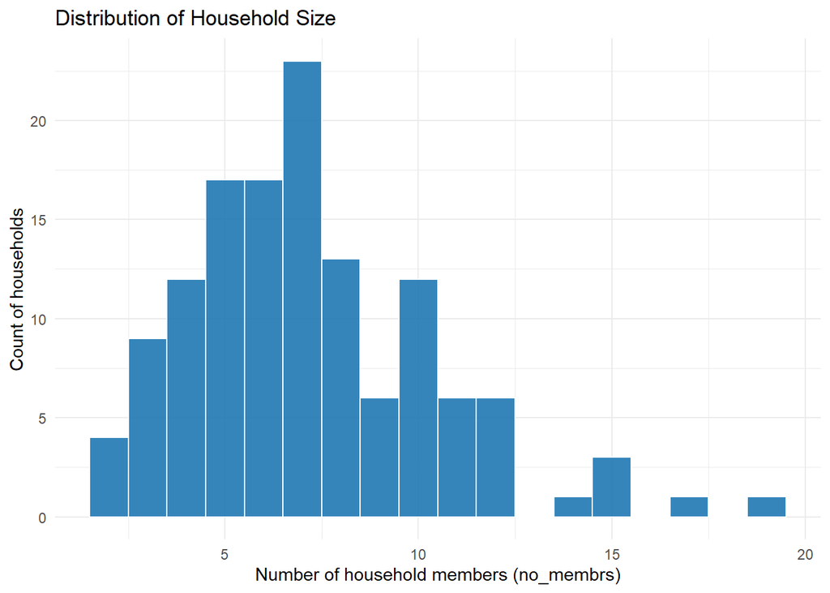

```r
safi %>%
  filter(!is.na(no_membrs)) %>%
  ggplot(aes(x = no_membrs)) +
  geom_histogram(binwidth = 1, fill = "#1f78b4", color = "white", alpha = 0.9) +
  labs(
    title = "Distribution of Household Size",
    x = "Number of household members (no_membrs)",
    y = "Count of households"
  ) +
  theme_minimal()
```

**Explanation (chart):** a histogram shows the frequency of households by size. This helps answer questions like “What is a typical household size?” and whether there are outliers.

### 5.2 Meals per day (food consumption indicator)

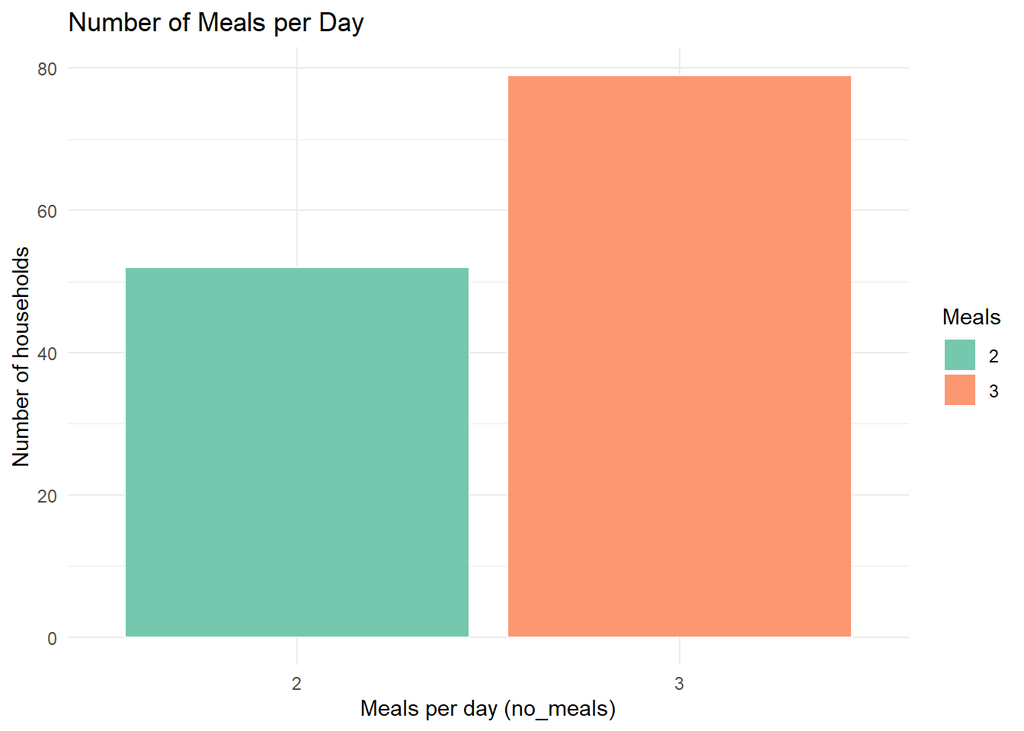

```r
safi %>%
  filter(!is.na(no_meals)) %>%
  ggplot(aes(x = factor(no_meals), fill = factor(no_meals))) +
  geom_bar(color = "white", alpha = 0.9) +
  labs(
    title = "Number of Meals per Day",
    x = "Meals per day (no_meals)",
    y = "Number of households",
    fill = "Meals"
  ) +
  scale_fill_brewer(palette = "Set2") +
  theme_minimal()
```

**Explanation (chart):** a bar chart is appropriate for discrete values like meals per day. It shows the most common meal counts (e.g., 2 or 3) and whether uncommon values appear.

### 5.3 Household size vs meals per day

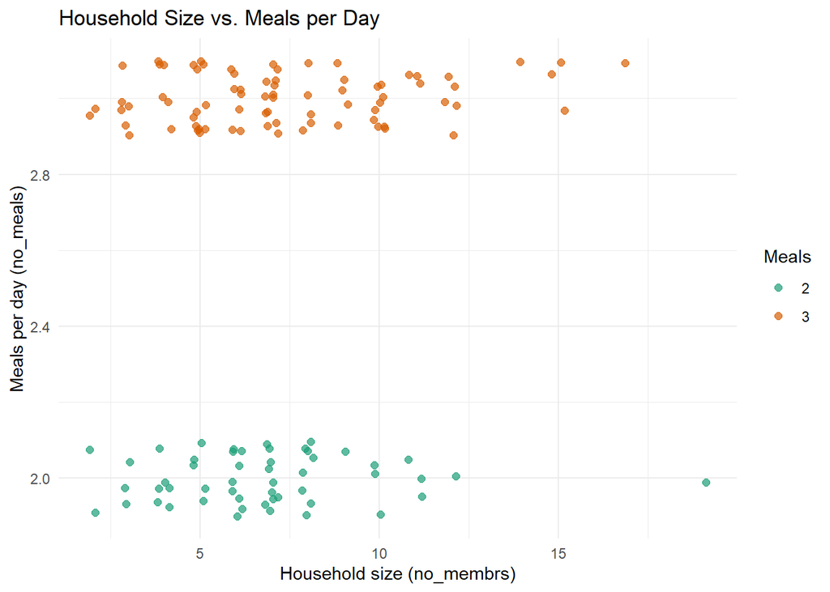

```r
safi %>%
  filter(!is.na(no_membrs), !is.na(no_meals)) %>%
  ggplot(aes(x = no_membrs, y = no_meals, color = factor(no_meals))) +
  geom_jitter(width = 0.2, height = 0.1, alpha = 0.7, size = 2) +
  labs(
    title = "Household Size vs. Meals per Day",
    x = "Household size (no_membrs)",
    y = "Meals per day (no_meals)",
    color = "Meals"
  ) +
  scale_color_brewer(palette = "Dark2") +
  theme_minimal()
```

**Explanation (chart):** this plot checks whether meals per day change with household size. It is a visual check for association only and does not imply causality.

## 6. Short findings

- **Household size** varies across the dataset.
- **Meals per day** are concentrated in a few discrete categories.
- The **household size vs meals** plot shows no strong visual relationship.

## 7. Conclusion

This short EDA confirms the dataset loads correctly, provides a first look at distributions, missingness, and basic relationships.